# Analysis 3: Statistical Programming with Daily Delhi Climate Data

Sarah Bazari

July 14, 2025

# Instructions

**Overview:** For each question, show your R code that you used to answer each question in the provided chunks. When a written response is required, be sure to answer the entire question in complete sentences outside the code chunks. When figures are required, be sure to follow all requirements to receive full credit. Point values are assigned for every part of this analysis.

**Helpful:** Make sure you knit the document as you go through the assignment. Check all your results in the created HTML file.

**Submission:** Submit via an electronic document on Canvas. Must be submitted as an HTML file generated in RStudio.

# Introduction

For this assignment, we will be using daily climate time series data in the city of Delhi between 2013 and 2017. This data was found on [Kaggle](https://www.kaggle.com/sumanthvrao/daily-climate-time-series-data) and was collected from Weather Underground API.

Below is a preview of the 2 datasets. The tibble named `DELHI.TRAIN` contains daily temperature, humidity, wind speed, and pressure measurements from 2013 and 2016. The tibble named `DELHI.TEST` contains the same information for 2017. The purpose of the test set is to evaluate our conclusions from analyses done on the train set.

```r
DELHI.TRAIN=as.tibble(read.csv("DailyDelhiClimateTrain.csv"))[-1462,]    #DO NOT CHANGE
DELHI.TEST=as.tibble(read.csv("DailyDelhiClimateTest.csv"))              #DO NOT CHANGE
head(DELHI.TRAIN)                                                        #DO NOT CHANGE
```

```
## # A tibble: 6 × 5
##   date       meantemp humidity wind_speed meanpressure
##   <chr>         <dbl>    <dbl>      <dbl>        <dbl>
## 1 2013-01-01    10        84.5       0           1016.
## 2 2013-01-02     7.4      92         2.98        1018.
## 3 2013-01-03     7.17     87         4.63        1019.
## 4 2013-01-04     8.67     71.3       1.23        1017.
## 5 2013-01-05     6        86.8       3.7         1016.
## 6 2013-01-06     7        82.8       1.48        1018
```

```r
head(DELHI.TEST)                                                         #DO NOT CHANGE
```

```
## # A tibble: 6 × 5
##   date       meantemp humidity wind_speed meanpressure
##   <chr>         <dbl>    <dbl>      <dbl>        <dbl>
## 1 2017-01-01     15.9     85.9       2.74          59
## 2 2017-01-02     18.5     77.2       2.89        1018.
## 3 2017-01-03     17.1     81.9       4.02        1018.
## 4 2017-01-04     18.7     70.0       4.54        1016.
## 5 2017-01-05     18.4     74.9       3.3         1014.
## 6 2017-01-06     19.3     79.3       8.68        1012.
```

Follow the steps to accomplish specific tasks, and do not modify code on lines with the comment `#DO NOT CHANGE`. Add code in R code chunks wherever you see `COMPLETE`. Follow instructions in each problem. If I ask you to create a loop, then you must create a loop. If I ask you to use if-else, you must use if-else.

# Assignment

## Part 1: Cleaning Data

We want to start by cleaning the two datasets.

### Q1 *(2 Points)*

Observe how the following code applied to `DELHI.TRAIN` creates a “date” variable, splits up the original date variable into year, month, and day, converts thee previously mentioned variables to numeric, renames the weather variables, and then selects variables we want.

```r
DELHI.TRAIN %>%                                                    #DO NOT CHANGE
  mutate(Date = as_date(date)) %>%                                 #DO NOT CHANGE
  separate(date,into=c("Year","Month","Day"),sep="-") %>%          #DO NOT CHANGE
  mutate_at(1:3,as.numeric) %>%                                    #DO NOT CHANGE
  rename("Temperature"="meantemp","Humidity"="humidity",           #DO NOT CHANGE
         "Wind"="wind_speed","Pressure"="meanpressure") %>%        #DO NOT CHANGE
  select(Date,Temperature,Humidity,Wind,Pressure,Year,Month,Day)   #DO NOT CHANGE
```

```
## # A tibble: 1,461 × 8
##    Date       Temperature Humidity  Wind Pressure  Year Month   Day
##    <date>           <dbl>    <dbl> <dbl>    <dbl> <dbl> <dbl> <dbl>
##  1 2013-01-01       10        84.5  0       1016.  2013     1     1
##  2 2013-01-02        7.4      92    2.98    1018.  2013     1     2
##  3 2013-01-03        7.17     87    4.63    1019.  2013     1     3
##  4 2013-01-04        8.67     71.3  1.23    1017.  2013     1     4
##  5 2013-01-05        6        86.8  3.7     1016.  2013     1     5
##  6 2013-01-06        7        82.8  1.48    1018   2013     1     6
##  7 2013-01-07        7        78.6  6.3     1020   2013     1     7
##  8 2013-01-08        8.86     63.7  7.14    1019.  2013     1     8
##  9 2013-01-09       14        51.2 12.5     1017   2013     1     9
## 10 2013-01-10       11        62    7.4     1016.  2013     1    10
## # ℹ 1,451 more rows
```

Create a function named `clean.func()` that takes one argument called “data” and then does everything from the code above. We want to generalize the code above so we can run the function on both datasets `DELHI.TRAIN` and `DELHI.TEST`. We want to use this function to modify both original datasets `DELHI.TRAIN` and `DELHI.TEST` to `TRAIN.CLEAN` and `TEST.CLEAN`, respectively. We can do this since both of the orginal datasets are organized the same way and have the same variable names.

Code and Output:

```r
# generalize the code --> og code works only on 'DEHLI.TRAIN'
# but we want it to work with both data sets
# goal is to wrap code above in a function and pass dataset as arg

clean.func = function(data){

  cleaned_data = data %>%
    mutate(Date = as_date(date)) %>% # creates date variable
    separate(date, into = c("Year", "Month", "Day", sep = "-")) %>% # splits date into 3 parts
    mutate_at(1:3, as.numeric) %>% # converts separated data to numeric
    rename(
      "Temperature" = "meantemp",
      "Humidity" = "humidity",
      "Wind" = "wind_speed",
      "Pressure" = "meanpressure"
    ) %>%
    select(Date, Temperature, Humidity, Wind, Pressure, Year, Month, Date)

  return(cleaned_data)
}

TRAIN.CLEAN=clean.func(DELHI.TRAIN) #DO NOT CHANGE
TEST.CLEAN=clean.func(DELHI.TEST) #DO NOT CHANGE
head(TRAIN.CLEAN) #DO NOT CHANGE
```

```
## # A tibble: 6 × 7
##   Date       Temperature Humidity  Wind Pressure  Year Month
##   <date>           <dbl>    <dbl> <dbl>    <dbl> <dbl> <dbl>
## 1 2013-01-01       10        84.5  0       1016.  2013     1
## 2 2013-01-02        7.4      92    2.98    1018.  2013     1
## 3 2013-01-03        7.17     87    4.63    1019.  2013     1
## 4 2013-01-04        8.67     71.3  1.23    1017.  2013     1
## 5 2013-01-05        6        86.8  3.7     1016.  2013     1
## 6 2013-01-06        7        82.8  1.48    1018   2013     1
```

```r
head(TEST.CLEAN) #DO NOT CHANGE
```

```
## # A tibble: 6 × 7
##   Date       Temperature Humidity  Wind Pressure  Year Month
##   <date>           <dbl>    <dbl> <dbl>    <dbl> <dbl> <dbl>
## 1 2017-01-01        15.9     85.9  2.74      59   2017     1
## 2 2017-01-02        18.5     77.2  2.89    1018.  2017     1
## 3 2017-01-03        17.1     81.9  4.02    1018.  2017     1
## 4 2017-01-04        18.7     70.0  4.54    1016.  2017     1
## 5 2017-01-05        18.4     74.9  3.3     1014.  2017     1
## 6 2017-01-06        19.3     79.3  8.68    1012.  2017     1
```

### Q2 *(2 Points)*

In the following code, I create a numeric vector called `month` that contains values 1 for January and 2 for February. Observe how the following code rewrites over the original numeric vector `month` to a categorical vector with the names of months rather than the original numbers.

```r
month=c(1,2,2,1,2,2,1,2,1,2)  #DO NOT CHANGE

if(month[1]==1){          #DO NOT CHANGE
  month[1]="January"          #DO NOT CHANGE
} else if(month[1]==2){       #DO NOT CHANGE
  month[1]="February"         #DO NOT CHANGE
}                         #DO NOT CHANGE

if(month[2]==1){          #DO NOT CHANGE
  month[2]="January"          #DO NOT CHANGE
} else if(month[2]==2){       #DO NOT CHANGE
  month[2]="February"         #DO NOT CHANGE
}                         #DO NOT CHANGE

if(month[3]==1){          #DO NOT CHANGE
  month[3]="January"          #DO NOT CHANGE
} else if(month[3]==2){       #DO NOT CHANGE
  month[3]="February"         #DO NOT CHANGE
}                         #DO NOT CHANGE

print(month)                 #DO NOT CHANGE
```

```
##  [1] "January"  "February" "February" "1"        "2"        "2"
##  [7] "1"        "2"        "1"        "2"
```

Create a function called `month.func` that has one argument `month` (this would ideally be a numeric vector with discrete values 1 through 12) and rewrites over the initial vector `month` to contain month names from “January” to “December” rather than numbers.

After creating two new datasets identical to the previous datasets, we rewrite over the original variables named `Month` using our new function applied to the old variable. The “dollar sign” can be used to access variables from datasets and even create new variables from datasets.

Code and Output:

```r
month.func = function(month){

  # want to loop over each elem in the month vector
  for (i in 1:length(month)) { # use a loop 'for (i in 1:length(month)')
    # updates values in place, returns new month vector
    # make sure to use assignment ( = instead of == ) initial error
    if (month[i] == 1) {
      month[i] = "January"
    } else if (month[i] == 2) {
      month[i] = "February"
    } else if (month[i] == 3) {
      month[i] = "March"
    } else if (month[i] == 4) {
      month[i] = "April"
    } else if (month[i] == 5) {
      month[i] = "May"
    } else if (month[i] == 6) {
      month[i] = "June"
    } else if (month[i] == 7) {
      month[i] = "July"
    } else if (month[i] == 8) {
      month[i] = "August"
    } else if (month[i] == 9) {
      month[i] = "September"
    } else if (month[i] == 10) {
      month[i] = "October"
    } else if (month[i] == 11) {
      month[i] = "November"
    } else if (month[i] == 12) {
      month[i] = "December"
    }
 }

  return(month)
}

TRAIN.CLEAN.2=TRAIN.CLEAN #DO NOT CHANGE
TEST.CLEAN.2=TEST.CLEAN #DO NOT CHANGE
TRAIN.CLEAN.2$Month=month.func(TRAIN.CLEAN$Month) #DO NOT CHANGE
TEST.CLEAN.2$Month=month.func(TEST.CLEAN$Month) #DO NOT CHANGE
unique(TRAIN.CLEAN.2$Month) #DO NOT CHANGE
```

```
##  [1] "January"   "February"  "March"     "April"     "May"       "June"
##  [7] "July"      "August"    "September" "October"   "November"  "December"
```

```r
unique(TEST.CLEAN.2$Month) #DO NOT CHANGE
```

```
## [1] "January"  "February" "March"    "April"
```

### Q3 *(2 Points)*

Currently, the data is sorted by date starting with January 1, 2013. Our goal is to change all of the numeric values for day to “Tuesday”, “Wednesday”, Thursday”, etc. Run the following code line-by-line and observe how the `rep()`function works.

```r
rep(c("Bill","Ted"),times=5)        #DO NOT CHANGE
```

```
##  [1] "Bill" "Ted"  "Bill" "Ted"  "Bill" "Ted"  "Bill" "Ted"  "Bill" "Ted"
```

```r
rep(c("Bill","Ted"),each=2,times=4) #DO NOT CHANGE
```

```
##  [1] "Bill" "Bill" "Ted"  "Ted"  "Bill" "Bill" "Ted"  "Ted"  "Bill" "Bill"
## [11] "Ted"  "Ted"  "Bill" "Bill" "Ted"  "Ted"
```

```r
rep(c("Bill","Ted"),length.out=11)  #DO NOT CHANGE
```

```
##  [1] "Bill" "Ted"  "Bill" "Ted"  "Bill" "Ted"  "Bill" "Ted"  "Bill" "Ted"
## [11] "Bill"
```

```r
rep(c("Bill","Ted"),length.out=12)  #DO NOT CHANGE
```

```
##  [1] "Bill" "Ted"  "Bill" "Ted"  "Bill" "Ted"  "Bill" "Ted"  "Bill" "Ted"
## [11] "Bill" "Ted"
```

Now, you must use the `rep()` function to overwrite the `Day` variable replacing the day of the month with the name of the day. For this, it is important to know that the first day in the training set is a Tuesday. Assume there are no days missing data between the first observation in the training set and the last observation of the testing set. Also, notice how the last observation in the training set is December 31, 2016, and the first observation in the testing set is January 1, 2017. If you don’t use the `rep()` function you will get 0 points.

Code and Output:

```r
# overwriting 'Day' column in train and test sets
# so that each row tells what day of the week it is, rather than DOM

TRAIN.CLEAN.3=TRAIN.CLEAN.2 #DO NOT CHANGE
TEST.CLEAN.3=TEST.CLEAN.2   #DO NOT CHANGE

# using rep() to create repeating weekday patterns
# rep(x, length.out = n) --> want result of pattern x to have n elements after repetition

# need to replace the 'Day' column with weekday names
TRAIN.CLEAN.3$Day = rep(
  c("Tuesday", "Wednesday", "Thursday", "Friday", "Saturday", "Sunday", "Monday"),
  length.out = nrow(TRAIN.CLEAN.3) # makes the vector repeat until it matches the number of rows
  )

TEST.CLEAN.3$Day  = rep(
  c("Sunday", "Monday", "Tuesday", "Wednesday", "Thursday", "Friday", "Saturday"),
  length.out = nrow(TEST.CLEAN.3)
)

# overwrites entire Day column with this corrected vector of weekdays

unique(TRAIN.CLEAN.3$Day[c(1,1461)]) #DO NOT CHANGE: Shows Tuesday and Saturday
```

```
## [1] "Tuesday"  "Saturday"
```

```r
unique(TEST.CLEAN.3$Day[c(1,114)]) #DO NOT CHANGE: Shows Sunday and Monday
```

```
## [1] "Sunday" "Monday"
```

### Q4 *(2 Points)*

I want you to create a function called `cels.2.fahr()` that converts a temperature (or vector of temperatures) measured in Celsius to the equivalent temperature(s) in Fahrenheit. Google the formula necessary for this conversion.

Code and Output:

```r
cels.2.fahr = function(celsius) {
  fahrenheit = celsius * 9/5 + 32 # conversion formula

  return(fahrenheit) # outputs converted values
}

TRAIN.FINAL=TRAIN.CLEAN.3 #DO NOT CHANGE
TEST.FINAL=TEST.CLEAN.3   #DO NOT CHANGE
TRAIN.FINAL$Temperature=cels.2.fahr(TRAIN.CLEAN.3$Temperature) #DO NOT CHANGE
TEST.FINAL$Temperature=cels.2.fahr(TEST.CLEAN.3$Temperature) #DO NOT CHANGE
TRAIN.FINAL$Temperature[1:10] #DO NOT CHANGE
```

```
##  [1] 50.00000 45.32000 44.90000 47.60000 42.80000 44.60000 44.60000 47.94286
##  [9] 57.20000 51.80000
```

```r
TEST.FINAL$Temperature[1:10] #DO NOT CHANGE
```

```
##  [1] 60.64348 65.30000 62.80000 65.66000 65.10000 66.77273 58.47500 60.23158
##  [9] 58.22857 53.80000
```

## Part 2: Statistical Programming Problems on Cleaned Data

### Q1 *(4 Points)*

We want to approximate the 95% confidence interval for the average humidity of each combination of month and day. Use the formula, $\bar{x}\pm 2*s_x/\sqrt{n}$. In this formula, $\bar{x}$ would be the average humidity for all observations in a specific month and specific day. Likewise, $s_x$ is the sample standard deviation of the humidity for all observations in a specific month and specific day.

We want to get a 95% confidence interval for every combination of month and day. To do this, we want to create two matrices `LB.HUMID.TRAIN` and `UB.HUMID.TRAIN` that will contain the lower bound and upper bound of each confidence interval, respectively. We start by creating these two matrices full of missing values.

Use a double loop to fill in each matrix with the appropriate bound of the confidence interval for each combination of month and day. For example, the element in row 1 and column 1 of `LB.HUMID.TRAIN` should contain the lower bound of the 95% confidence interval for the average humidity for all Mondays in January. Likewise, the element in row 2 and column 2 of `UB.HUMID.TRAIN` should contain the upper bound of the 95% confidence interval for the average humidity for all Tuesdays in February.

Hint: Notice the loop goes from 1 to 12 and 1 to 7, but you will need to figure out how to convert these numbers to the appropriate months and days in words to filter the data since we cleaned the data to show the words only.

Code and Output:

```r
LB.HUMID.TRAIN=matrix(NA,12,7) #DO NOT CHANGE
rownames(LB.HUMID.TRAIN)=c("January","February","March","April","May","June",         #DO NOT CHANGE
                         "July","August","September","October","November","December")  #DO NOT CHANGE
colnames(LB.HUMID.TRAIN)=c("Monday","Tuesday","Wednesday",        #DO NOT CHANGE
                         "Thursday","Friday","Saturday","Sunday")  #DO NOT CHANGE

UB.HUMID.TRAIN=matrix(NA,12,7) #DO NOT CHANGE
rownames(UB.HUMID.TRAIN)=c("January","February","March","April","May","June",         #DO NOT CHANGE
                         "July","August","September","October","November","December")  #DO NOT CHANGE
colnames(UB.HUMID.TRAIN)=c("Monday","Tuesday","Wednesday",        #DO NOT CHANGE
                         "Thursday","Friday","Saturday","Sunday")  #DO NOT CHANGE

#Run this code and think about what it is doing
rownames(LB.HUMID.TRAIN)[11] #DO NOT CHANGE
```

```
## [1] "November"
```

```r
colnames(UB.HUMID.TRAIN)[5] #DO NOT CHANGE
```

```
## [1] "Friday"
```

```r
for(j in 1:12){    #DO NOT CHANGE
  for(k in 1:7){   #DO NOT CHANGE

    # need to get actual month and weekday names for indexing
    month_names = rownames(LB.HUMID.TRAIN)[j]
    weekday_names = colnames(LB.HUMID.TRAIN)[k]

    # need to filter 'TRAIN.FINAL' for the month and day of interest
    filtered = TRAIN.FINAL %>%
      filter(Month == month_names, Day == weekday_names)

    # need to avoid divisions by NA or 0
    # checks if there are data points in that combo
    # calculating mean, sd, and num observations in group
    if (nrow(filtered) > 0) {
      xbar = mean(filtered$Humidity) # sample mean humidity
      sd = sd(filtered$Humidity) # sample sd of humidity
      n = nrow(filtered) # and number observations seen in this particular grouping

    # to compute lower and upper bounds of 95% confidence interval
      LB.HUMID.TRAIN[j, k] = xbar - 2 * sd / sqrt(n) # lower
      UB.HUMID.TRAIN[j, k] = xbar + 2 * sd / sqrt(n) # upper

  }                #DO NOT CHANGE
}                  #DO NOT CHANGE
}
print(LB.HUMID.TRAIN) #DO NOT CHANGE
```

```
##             Monday  Tuesday Wednesday Thursday   Friday Saturday   Sunday
## January   73.35212 73.06359  73.13740 73.88686 73.35434 74.16065 76.11802
## February  63.78646 62.70323  64.46890 57.48614 61.65277 65.46764 65.90723
## March     56.56023 56.40771  54.26862 54.27694 53.56427 57.25987 57.75037
## April     34.47873 33.35440  33.18442 32.18770 33.05809 31.24513 32.91167
## May       31.44475 33.08357  28.38924 28.54668 29.43737 32.88345 29.89440
## June      45.43287 43.89523  43.54767 44.61247 41.81293 43.98038 44.67219
## July      67.48047 64.74622  62.64996 61.59474 64.44154 66.17900 67.43856
## August    64.24940 63.32273  62.58998 63.64523 65.20480 67.26559 66.31242
## September 55.55096 53.35730  54.47129 56.49625 56.66954 56.64351 56.96340
## October   56.23199 57.79475  58.25694 56.20256 56.41837 57.45010 56.91665
## November  52.81817 54.70319  55.99419 56.73921 56.46184 58.02190 55.15208
## December  63.75524 66.44686  66.74456 68.39377 69.25943 67.82986 67.62773
```

```r
print(UB.HUMID.TRAIN) #DO NOT CHANGE
```

```
##             Monday  Tuesday Wednesday Thursday   Friday Saturday   Sunday
## January   81.29401 81.54356  84.41022 83.16878 84.47818 83.99226 81.68968
## February  70.09804 72.82143  71.48177 68.77964 73.84736 78.25885 74.79925
## March     68.34545 66.54851  64.79616 61.03061 62.35442 66.39417 69.14355
## April     46.77653 44.66505  44.29237 42.96442 46.36418 44.67641 46.46750
## May       45.54986 45.10545  41.47754 37.85116 37.66547 41.07707 38.78582
## June      59.04927 60.60043  56.95912 58.03157 52.33931 54.21717 58.90730
## July      77.23368 75.08712  73.67473 72.82332 77.70555 80.47659 78.32432
## August    74.48627 76.41585  74.86145 75.39199 75.97171 77.31144 78.98074
## September 63.88590 61.08551  64.57417 69.18278 67.23954 68.07402 66.67247
## October   62.97857 65.24297  65.55961 63.93082 67.86607 66.20223 66.04857
## November  63.76742 62.90243  63.92693 64.88648 68.35810 69.33728 65.23754
## December  76.28998 77.36509  75.29986 77.06615 77.79748 79.70252 80.42857
```

### Q2 *(4 Points)*

Run the following code line-by-line and observe what is happening. I am calculating the proportion of the measures that are within the interval based on the lower bound and upper bound.

```r
lowerbound=30 #DO NOT CHANGE
upperbound=50 #DO NOT CHANGE

measures = c(23, 40, 51, 68, 72, 63, 19) #DO NOT CHANGE

mean(measures > lowerbound & measures < upperbound) #DO NOT CHANGE
```

```
## [1] 0.1428571
```

The object `PROP.HUMID.TEST` is a matrix of the same size as `LB.HUMID.TRAIN` and `UB.HUMID.TRAIN`. For each combination of month and day, I want you to calculate the proportion of time the observed humidity in the test set `TEST.FINAL` is within the 95% confidence interval for the population mean that was estimated from the training set. For example, the element in the third row and fourth column of `PROP.HUMID.TEST` should tell you what proportion of all the Thursdays in March for the year 2017 had a humidity between the element in the third row and fourth column of `LB.HUMID.TRAIN` and the element the third row and fourth column of `UB.HUMID.TRAIN`.

Code and Output:

```r
PROP.HUMID.TEST = matrix(NA,12,7) #DO NOT CHANGE

rownames(PROP.HUMID.TEST)=c("January","February","March","April","May","June",         #DO NOT CHANGE
                         "July","August","September","October","November","December")  #DO NOT CHANGE
colnames(PROP.HUMID.TEST)=c("Monday","Tuesday","Wednesday",        #DO NOT CHANGE
                         "Thursday","Friday","Saturday","Sunday")  #DO NOT CHANGE

# how to check for within interval values
# mean(values > lowerbound & values < upperbound)


for(j in 1:12){         #DO NOT CHANGE
  for(k in 1:7){        #DO NOT CHANGE

    # need to get names for loop
    month_names = rownames(PROP.HUMID.TEST)[j]
    weekday_names = colnames(PROP.HUMID.TEST)[k]

    # need to filter 'TEST.FINAL' to get only rows with the month n day
    filtered_again = TEST.FINAL %>%
      filter(Month == month_names, Day == weekday_names)

    # loop
    if (nrow(filtered_again) > 0) {

      # this is getting humidity values from grouping
      humidity_pts = filtered_again$Humidity

      # using lower and upper bounds from training set
      lower = LB.HUMID.TRAIN[month_names, weekday_names]
      upper = UB.HUMID.TRAIN[month_names, weekday_names]

      # calculate proportions of the test vals between the two bounds
      proportion_in_test = mean(humidity_pts > lower & humidity_pts < upper)

      # then we need to store these inside a matrix separately
      PROP.HUMID.TEST[month_names, weekday_names] = proportion_in_test


  }                     #DO NOT CHANGE
}                       #DO NOT CHANGE
}
print(PROP.HUMID.TEST) #DO NOT CHANGE
```

```
##           Monday Tuesday Wednesday Thursday    Friday Saturday Sunday
## January     1.00    0.20      0.25     0.75 0.5000000     0.50    0.2
## February    0.50    0.75      0.50     0.50 0.5000000     0.50    0.5
## March       0.00    0.00      0.20     0.00 0.2000000     0.25    0.0
## April       0.25    0.00      0.00     0.00 0.6666667     0.50    0.5
## May           NA      NA        NA       NA        NA       NA     NA
## June          NA      NA        NA       NA        NA       NA     NA
## July          NA      NA        NA       NA        NA       NA     NA
## August        NA      NA        NA       NA        NA       NA     NA
## September     NA      NA        NA       NA        NA       NA     NA
## October       NA      NA        NA       NA        NA       NA     NA
## November      NA      NA        NA       NA        NA       NA     NA
## December      NA      NA        NA       NA        NA       NA     NA
```

### Q3 *(4 Points)*

Skewness can be measured by dividing the difference between the sample mean and the sample median by the sample standard deviation. Mathematically, this can be written as $Skew = \frac{\bar{x}-MEDIAN_x}{s_x}$.

In the dataset `TRAIN.FINAL`, we have daily temperatures for the years 2013 to 2016 and months January to December. The empty matrix `SKEW.TEMP.TRAIN` contains 4 rows for the 4 different years and 12 columns for the 12 different months. I want to replace the NA’s in `SKEW.TEMP.TRAIN` with the estimated skewness of all temperatures from `TRAIN.FINAL` for each combination of year and month. For example, the element in the 3rd row and 8th column of `SKEW.TEMP.TRAIN` should contain the skewness (based on formula) calculated on all daily temperatures from August 2015.

In this loop, I want you to loop through the years and the month names instead of 1:4 and 1:12. You need to figure out how to convert the year and month to appropriate numeric values for saving the skewness into `SKEW.TEMP.TRAIN`

Code and Output:

```r
SKEW.TEMP.TRAIN=matrix(NA,4,12) #DO NOT CHANGE
rownames(SKEW.TEMP.TRAIN)=unique(TRAIN.FINAL$Year)  #DO NOT CHANGE
colnames(SKEW.TEMP.TRAIN)=unique(TRAIN.FINAL$Month)  #DO NOT CHANGE

#Run this code and think about what it is doing
which(unique(TRAIN.FINAL$Year)==2015)   #DO NOT CHANGE
```

```
## [1] 3
```

```r
which(unique(TRAIN.FINAL$Month)=="August")   #DO NOT CHANGE
```

```
## [1] 8
```

```r
for(j in 2013:2016){                     #DO NOT CHANGE
  for(k in unique(TRAIN.FINAL$Month)){   #DO NOT CHANGE

  # need to filter 'TRAIN.FINAL' for current year and month
  data_subset = TRAIN.FINAL %>%
    filter(Year == j, Month == k)

  # need to compute based on amount of data
  if (nrow(data_subset) > 1) {
    x = data_subset$Temperature # get temperature values

    xbar = mean(x)
    med = median(x)
    sd = sd(x)

    skew = (xbar - med) / sd

    # now need to get matrix positions
    row_idx = which(rownames(SKEW.TEMP.TRAIN) == as.character(j))
    col_idx = which(colnames(SKEW.TEMP.TRAIN) == k)

    # now we store it
    SKEW.TEMP.TRAIN[row_idx, col_idx] = skew

  }                     #DO NOT CHANGE
}                      #DO NOT CHANGE
}
print(SKEW.TEMP.TRAIN) #DO NOT CHANGE
```

```
##         January    February       March       April         May        June
## 2013 -0.2475635  0.11989088 -0.14674838 -0.13060988  0.30197571 -0.04903584
## 2014  0.3686130  0.14059162 -0.05516756  0.23862821 -0.04069204 -0.01744156
## 2015 -0.2023132 -0.09212786  0.18708755 -0.05811273 -0.25402914  0.08274446
## 2016 -0.1526125  0.09738770  0.07120261 -0.23819171 -0.19943916 -0.27482073
##             July      August   September      October    November    December
## 2013 -0.05393872  0.06875057 -0.09739344 -0.005406163  0.24403685 -0.16104084
## 2014  0.18074350  0.02166961 -0.28608453  0.385189511  0.19768756 -0.10210267
## 2015  0.11924984 -0.03077630 -0.24710510 -0.464663927 -0.51895760 -0.00391693
## 2016 -0.05714150 -0.21627792  0.03770225  0.016707498 -0.07683968 -0.10262859
```

### Q4 *(2 Points)*

The `apply()` function is very helpful for applying functions to rows or columns of matrices. Google this function to see examples of how it is used.

Use `apply()` with the function `mean()` to create a vector called `AVG.SKEW.per.YEAR` that contains the average of each row in `SKEW.TEMP.TRAIN`.

Use `apply()` with the function `mean()` to create a vector called `AVG.SKEW.per.MONTH` that contains the average of each column in `SKEW.TEMP.TRAIN`.

Code and Output:

```r
# apply() to calculate average skewness per year
# and average skewness per month
# syntax --> apply(matrix, MARGIN, function)

# interpretation --> per years which had more positive/negative skewed temps
# are some months hotter (positive) or coler(neg) across years

AVG.SKEW.per.YEAR=apply(SKEW.TEMP.TRAIN, 1, mean, na.rm = TRUE)
AVG.SKEW.per.MONTH=apply(SKEW.TEMP.TRAIN, 2, mean, na.rm = TRUE)

print(AVG.SKEW.per.YEAR) #DO NOT CHANGE
```

```
##        2013        2014        2015        2016
## -0.01309023  0.08596956 -0.12357674 -0.09124598
```

```r
print(AVG.SKEW.per.MONTH) #DO NOT CHANGE
```

```
##     January    February       March       April         May        June
## -0.05846903  0.06643558  0.01409356 -0.04707153 -0.04804616 -0.06463842
##        July      August   September     October    November    December
##  0.04722828 -0.03915851 -0.14822020 -0.01704327 -0.03851822 -0.09242226
```

### Q5 *(8 Points)*

Run the following code line-by-line and observe what is happening.

```r
x=NULL   #DO NOT CHANGE
x=c(x,3) #DO NOT CHANGE
x=c(x,4) #DO NOT CHANGE
x=c(x,5) #DO NOT CHANGE
print(x) #DO NOT CHANGE
```

```
## [1] 3 4 5
```

Below, I created two empty objects named `SUMMER.WIND` and `WINTER.WIND`. I want you to loop through each row in `TRAIN.FINAL` moving through the data in chronological order. If the row involves a summer month (June, July, or August), I want you to add the wind speed of that day to `SUMMER.WIND`. If the row involves a winter month (December, January, or February), I want you to add the wind speed of that day to `WINTER.WIND`. For the rows involving other months, you should not add those wind speeds to either object, and you should ignore them.

Also, your code needs to utilize a loop and an if/if-else structure(s) or you will get 0 points. At the end, `SUMMER.WIND` and `WINTER.WIND` should be vectors.

Code and Output (4 Points):

```r
SUMMER.WIND=NULL #DO NOT CHANGE
WINTER.WIND=NULL #DO NOT CHANGE

for(j in 1:1461){             #DO NOT CHANGE

  current_month = TRAIN.FINAL$Month[j] # get current months row
  wind_val = TRAIN.FINAL$Wind[j] # get current wind speed row

  # check if summer month
  if (current_month %in% c("June", "July", "August")) {
    SUMMER.WIND = c(SUMMER.WIND, wind_val)
  # check if winter monmth

  } else if (current_month %in% c("December", "January", "Febuary")) {
    WINTER.WIND = c(WINTER.WIND, wind_val)
  }

}              #DO NOT CHANGE


t.test(x=SUMMER.WIND,y=WINTER.WIND) #DO NOT CHANGE
```

```
##
##  Welch Two Sample t-test
##
## data:  SUMMER.WIND and WINTER.WIND
## t = 8.3995, df = 514.19, p-value = 0.0000000000000004397
## alternative hypothesis: true difference in means is not equal to 0
## 95 percent confidence interval:
##  2.312437 3.724419
## sample estimates:
## mean of x mean of y
##  7.892030  4.873602
```

## Part 3: Creating Two New Variables Helpful for Time Series Data

When you have data that is organized chronologically, there are some cool features of the data we can explore using lags, differences, moving averages, moving ranges, etc. In this section, we will only create these variables in the training dataset named `TRAIN.FINAL`. Typically, we would also want to create these same variables in the testing dataset named `TEST.FINAL`.

### Q1 *(3 Points)*

We can create a new variable called `Temp_Change` in TRAIN.FINAL that currently contains all missing values. If we wanted to change the 4th observation of `Temp_Change` to 32, we could use the code `TRAIN.FINALTemp_Change[4]=32`. Each value of `Temp_Change` can be calculated from the following formula:

$\textrm{Temp_Change}=\textrm{Temperature Today}-\textrm{Temperature Yesterday}$

Use a loop to replace each missing value in the new variable called `Temp_Change` with the actual value according to the formula. If you don’t use a loop, you will lose points. Then, create a line plot that shows the change in the `Temp_Change` variable over time according to the `Date` variable. A line plot is useful when plotting a variable over time when there is only one measurement per time point. Also, Notice how the x-axis is formatted since we converted our original date variable to a “date” variable in R. Use the `ggplot2` package for making this graphic ONLY.

Code and Output:

```r
TRAIN.FINAL$Temp_Change=NA #DO NOT CHANGE

# loop through each day starting from second roqw
for (i in 2:nrow(TRAIN.FINAL)) {
  TRAIN.FINAL$Temp_Change[i] = TRAIN.FINAL$Temperature[i] - TRAIN.FINAL$Temperature[i-1]

}
# caqlculate differences in temp = temp_change
TRAIN.FINAL$Temp_Change[1:20] #DO NOT CHANGE
```

```
##  [1]        NA -4.680000 -0.420000  2.700000 -4.800000  1.800000  0.000000
##  [8]  3.342857  9.257143 -5.400000  8.485714 -3.085714  3.300000 -5.400000
## [15]  3.385714 -1.585714  4.800000 -4.800000 -2.400000 -2.185714
```

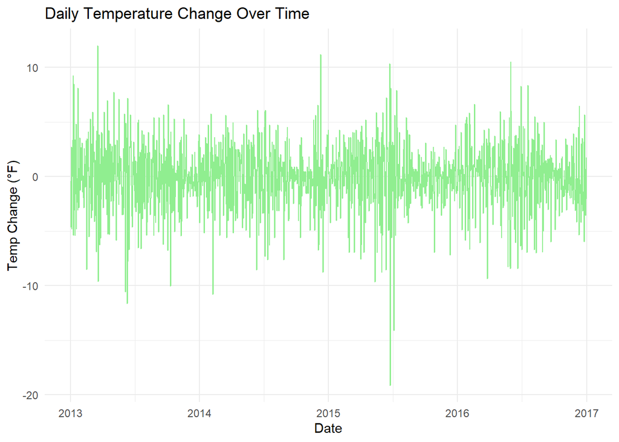

```r
#Put Code for Plot Here

ggplot(TRAIN.FINAL, aes(x = Date, y = Temp_Change)) +
  geom_line(color = "light green") +
  labs(title = "Daily Temperature Change Over Time",
       x = "Date",
       y = "Temp Change (°F)") +
  theme_minimal()
```

### Q2 *(7 Points)*

We create a new variable called `Temperature 3-Day Average` in `TRAIN.FINAL` that starts with all missing values. Each value of `Temperature 3-Day Average` represents a 3-day moving average and can be calculated from the following formula:

$\textrm{Temperature 3-Day Average}=\frac{\textrm{Temperature Yesterday}+\textrm{Temperature Today}+\textrm{Temperature Tomorrow}}{3}$

Also, we create a new variable called `Temperature 5-Day Average` in `TRAIN.FINAL` that starts with all missing values. Each value of `Temperature 5-Day Average` can be calculated using a formula similar to the one above. You will need to see the pattern.

Use a loop(s) to replace each missing value in the new variable called `Temperature 3-Day Average` with the actual value according to the formula, and replace each missing value in the new variable called `Temperature 5-Day Average` with the actual value according to a similar modified formula for a 5-day moving average. If you don’t use any loop(s), you will get 0 points.

Finally, I want you to use `ggplot2` functions to create a line plot with multiple lines. In this plot, the `Date` variable should be on the x-axis. The y-axis, should be called “Temperature”. There should be one line that shows the change in daily temperature for the dates in `TRAIN.FINAL`. There should be another line that shows the change in the 3-day moving average of temperature for the dates in `TRAIN.FINAL`. There should be one last line that shows the change in the 5-day moving average of temperature for the dates in `TRAIN.FINAL`. I want all three of these lines to have different colors and different line types (dashed, etc.). I want you to use a transparency of “alpha=0.2” for the line that you put on top of the other lines, and I want you to use a transparency of “alpha=0.6” for the line that you put in the middle of the two lines. I DO NOT want you to create a legend for these three lines.

Code and Output:

```r
TRAIN.FINAL$`Temperature 3-Day Average`=NA #DO NOT CHANGE
TRAIN.FINAL$`Temperature 5-Day Average`=NA #DO NOT CHANGE

# loop to calculate 3-day avg
for (i in 2:(nrow(TRAIN.FINAL) - 1)) {
  TRAIN.FINAL$'Temperature 3-Day Average'[i] = mean(TRAIN.FINAL$Temperature[(i - 2):(i + 2)])
}

# loop to calc 5-day average
for (i in 3:(nrow(TRAIN.FINAL) - 2)) {
  TRAIN.FINAL$'Temperature 5-Day Average'[i] = mean(TRAIN.FINAL$Temperature[(i - 2):(i + 2)])
}

TRAIN.FINAL$`Temperature 3-Day Average`[1:20] #DO NOT CHANGE
```

```
##  [1]       NA 46.95500 46.12400 45.04400 44.90000 45.50857 47.42857 49.22857
##  [9] 52.36571 54.88571 57.39714 56.97714 58.31429 57.63714 58.53714 57.81714
## [17] 57.69714 56.46286 55.51486 52.99486
```

```r
TRAIN.FINAL$`Temperature 5-Day Average`[1:20] #DO NOT CHANGE
```

```
##  [1]       NA       NA 46.12400 45.04400 44.90000 45.50857 47.42857 49.22857
##  [9] 52.36571 54.88571 57.39714 56.97714 58.31429 57.63714 58.53714 57.81714
## [17] 57.69714 56.46286 55.51486 52.99486
```

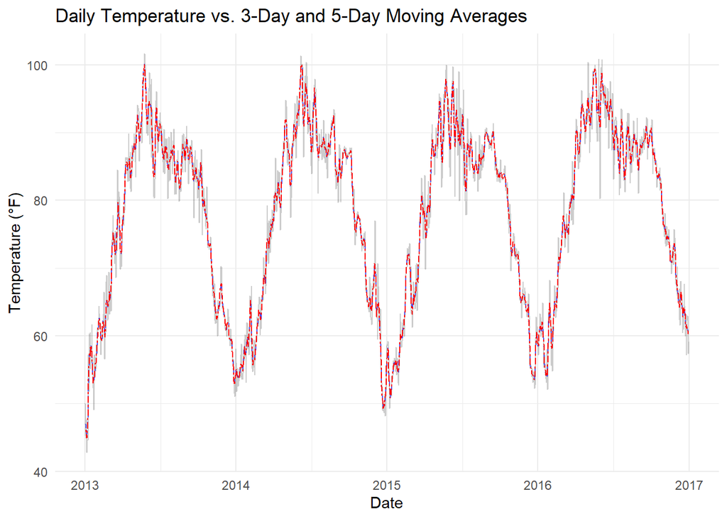

```r
#Put Code for Plot Here

ggplot(TRAIN.FINAL) +
  geom_line(aes(x = Date, y = Temperature), color = "black", linetype = "solid", alpha = 0.2) +
  geom_line(aes(x = Date, y = `Temperature 3-Day Average`), color = "blue", linetype = "dashed", alpha = 0.6) +
  geom_line(aes(x = Date, y = `Temperature 5-Day Average`), color = "red", linetype = "twodash", alpha = 1) +
  labs(title = "Daily Temperature vs. 3-Day and 5-Day Moving Averages",
       x = "Date",
       y = "Temperature (°F)") +
  theme_minimal()
```